# Homework 3

Yiming Gao (NetID: yimingg2)

2017/2/12

# Exercise 1

## Linear Regression

**(a) Plot the training data**

```r
# create the linear model
model_lm = lm(mpg ~ displacement, data = auto_train_data)
```

Then we plot the training data and add a line with the predicted probabilities. The dash line is $mpg = 0.5$.

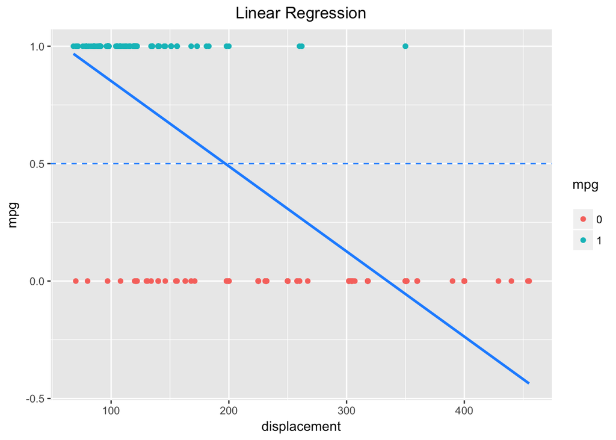

```r
library(ggplot2)
mydata1 = data.frame("displacement" = auto_train_data$displacement, "mpg" = auto_train_data$mpg)

ggplot(mydata1, aes(displacement, mpg))+
  # use colors based on the response category
  geom_point(aes(colour = factor(mpg)))+
  geom_smooth(method = "lm", se = FALSE, colour = "dodgerblue") +
  geom_hline(yintercept = 0.5, linetype = 2, colour = "dodgerblue") +
  labs(title = "Linear Regression",
       x = "displacement", y = "mpg", color = "mpg\n") +
  theme(plot.title = element_text(hjust = 0.5))
```

**(b) Find the decision boundary**

We want to find the decision boundary $c$ such that
$$\hat{C}(\text{displacement}) =
\begin{cases}
0 & \text{displacement} > c \\
1 & \text{displacement} \leq c
\end{cases}$$
Since `mpg` and `displacement` has linear relationship:

```r
model_lm$coefficients
```

```
##  (Intercept) displacement
##  1.214684137 -0.003628396
```

$$mpg = 1.215 -0.0036*displacement$$
When prediction of `mpg` is greater than $0.5$, than we classify it into **one**, otherwise, we classify it into **zero**. When $mpg = 0.5$, we have $displacement = 196.9697$. So we let $c = 196$, i.e.

$$\hat{C}(\text{displacement}) =
\begin{cases}
0 & \text{displacement} > 196 \\
1 & \text{displacement} \leq 196
\end{cases}$$

**(c) Find the test accuracy**

We have

- `Test Accuracy` = 0.913

```r
# obtain the predicted probabilities
lm_test_pred = ifelse(predict(model_lm, newdata = auto_test_data,
                                   type = "response") > 0.5, 1, 0)
# linear model test accuracy
lm_test_accuracy = mean(lm_test_pred == auto_test_data$mpg) # 0.913
lm_test_accuracy
```

```
## [1] 0.9130435
```

## Logistic Regression

**(a) Plot the training data**

First we create a logistic model with response `mpg` and the only predictor `displacement`, and plot the training data as well as the curve with the predicted probabilities.

```r
# create the logistic regression model
model_log = glm(mpg ~ displacement, data = auto_train_data, family = "binomial")
```

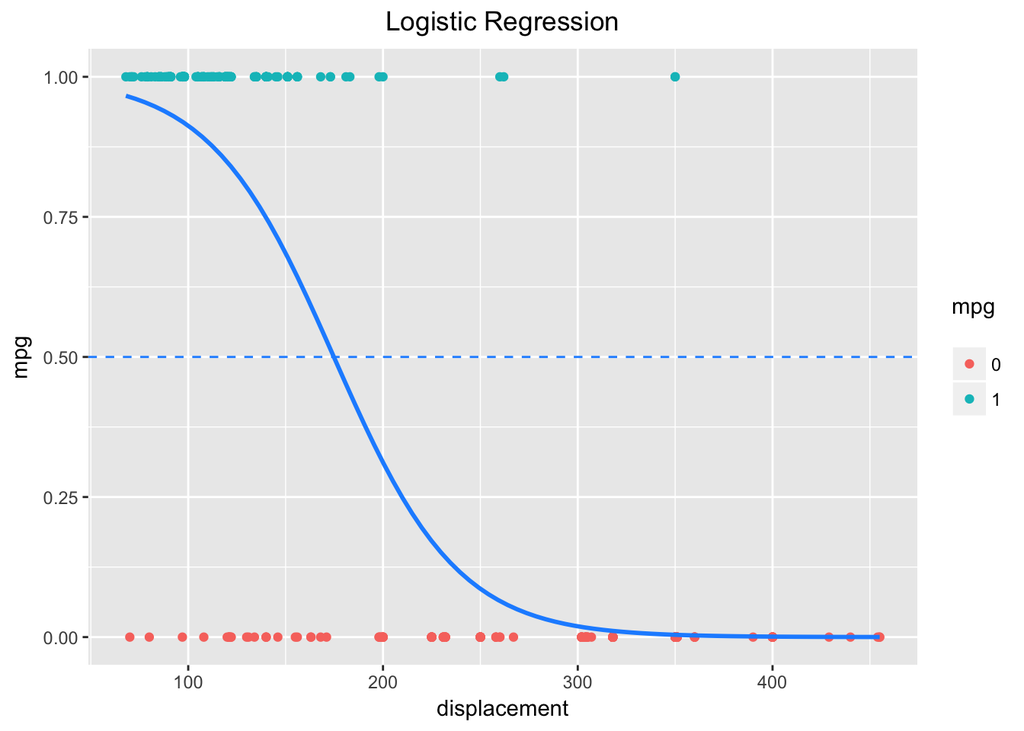

```r
ggplot(mydata1, aes(displacement, mpg))+
  # use colors based on the response category
  geom_point(aes(colour = factor(mpg)))+
  stat_smooth(method = "glm",method.args=list(family="binomial"),
              colour = "dodgerblue", se = F) +
  geom_hline(yintercept = 0.5, linetype = 2, colour = "dodgerblue") +
  labs(title = "Logistic Regression",
       x = "displacement", y = "mpg", color = "mpg\n") +
  theme(plot.title = element_text(hjust = 0.5))
```

**(b) Find the decision boundary**

We let $\hat{\beta_0} + \hat{\beta_1}*displacement = 0$, where $\hat{\beta_0}$ and $\hat{\beta_1}$ are given by:

```r
coef(model_log)[1]
```

```
## (Intercept)
##    5.484936
```

```r
coef(model_log)[2]
```

```
## displacement
##  -0.03138289
```

Thus $c = -\frac{\hat{\beta_0}}{\hat{\beta_1}}=\frac{5.485}{0.0314}=174.7747$. So we let $c = 174$, i.e.

$$\hat{C}(\text{displacement}) =
\begin{cases}
0 & \text{displacement} > 174 \\
1 & \text{displacement} \leq 174
\end{cases}$$

**(c) Find the test accuracy**

We have

- `Test Accuracy` = 0.913

```r
# obtain the predicted probabilities
log_test_pred = ifelse(predict.glm(model_log, newdata = auto_test_data,
                                   type = "response") > 0.5, 1, 0)
# linear model test accuracy
log_test_accuracy = mean(log_test_pred == auto_test_data$mpg) # 0.913
log_test_accuracy
```

```
## [1] 0.9130435
```

? So they have same accuracy?

# Exercise 2

**(a)**

First we fit the logistic regression model with two predictor `acceleration` and `weight`.

```r
# create the logistic regression model
model_log2 = glm(mpg ~ acceleration + weight,
                 data = auto_train_data, family = "binomial")
```

We want to calculate the decision boundary, which is the line performing
$$\hat{C(x)} =
\begin{cases}
1 & \hat{f}(x)>0 \\
0 & \hat{f}(x) \leq 0
\end{cases}$$
where
$$\hat{f}(x) = \hat{\beta_0}+\hat{\beta_1}*acceleration+\hat{\beta_2}*weight$$

We solve
$$\hat{\beta_0}+\hat{\beta_1}*acceleration+\hat{\beta_2}*weight=0$$
and get

$$weight = -\frac{\hat{\beta_0}}{\hat{\beta_2}}-\frac{\hat{\beta_1}}{\hat{\beta_2}}*acceleration$$
where $\hat{\beta_0}$ is the intercept, $\hat{\beta_1}$ and $\hat{\beta_2}$ are the corresponding coefficients for `acceleration` and `weight`.

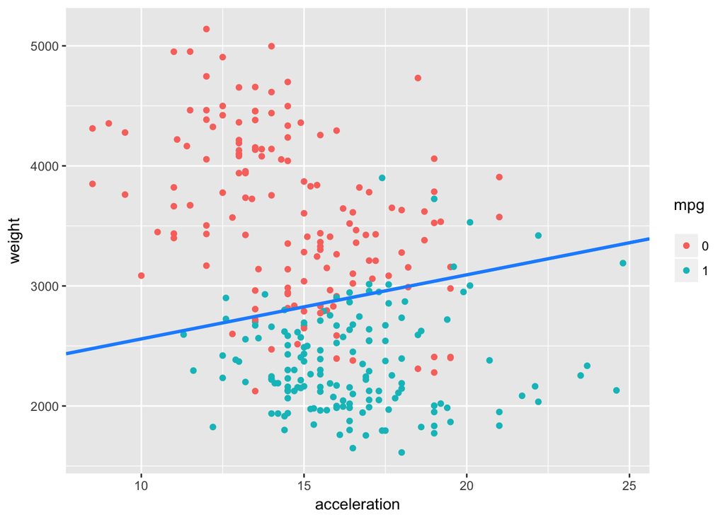

```r
mydata2 = data.frame("acceleration" = auto_train_data$acceleration, "weight" = auto_train_data$weight, "mpg" = auto_train_data$mpg)

ggplot(mydata2, aes(acceleration, weight))+
  # use colors based on the response category
  geom_point(aes(colour = factor(mpg)))+
  geom_abline(intercept = (- coef(model_log2)[1])/ (coef(model_log2)[3]),
              slope = - coef(model_log2)[2]/( coef(model_log2)[3]),
              colour = "dodgerblue", lwd = 1.1) +
  labs(x = "acceleration", y = "weight", color = "mpg\n")
```

We can see that the decision boundary separate out most of the red and blue points, which means our classifier works well.

**(b)**

Report test sensitivity, test specificity, and test accuracy for three classifiers, each using a different cutoff for predicted probability:

- 0.2
- 0.5
- 0.8

```r
get_pred = function(mod, data, res = "y", pos = 1, neg = 0, cut = 0.5) {
  probs = predict(mod, newdata = data, type = "response")
  ifelse(probs > cut, pos, neg)
}

test_pred_20 = get_pred(model_log2, data = auto_test_data, res = "default", pos = "1", neg = "0", cut = 0.2)
test_pred_50 = get_pred(model_log2, data = auto_test_data, res = "default", pos = "1", neg = "0", cut = 0.5)
test_pred_80 = get_pred(model_log2, data = auto_test_data, res = "default", pos = "1", neg = "0", cut = 0.8)

# confusion matrix
test_tab_20 = table(predicted = test_pred_20, actual = auto_test_data$mpg)
test_tab_50 = table(predicted = test_pred_50, actual = auto_test_data$mpg)
test_tab_80 = table(predicted = test_pred_80, actual = auto_test_data$mpg)

test_con_mat_20 = confusionMatrix(test_tab_20, positive = "1")
test_con_mat_50 = confusionMatrix(test_tab_50, positive = "1")
test_con_mat_80 = confusionMatrix(test_tab_80, positive = "1")

metrics = rbind(

  c(test_con_mat_20$overall["Accuracy"],
    test_con_mat_20$byClass["Sensitivity"],
    test_con_mat_20$byClass["Specificity"]),

  c(test_con_mat_50$overall["Accuracy"],
    test_con_mat_50$byClass["Sensitivity"],
    test_con_mat_50$byClass["Specificity"]),

  c(test_con_mat_80$overall["Accuracy"],
    test_con_mat_80$byClass["Sensitivity"],
    test_con_mat_80$byClass["Specificity"])

)

rownames(metrics) = c("c = 0.20", "c = 0.50", "c = 0.80")
round(metrics, 3)
```

```
##          Accuracy Sensitivity Specificity
## c = 0.20    0.837       1.000        0.70
## c = 0.50    0.902       0.929        0.88
## c = 0.80    0.880       0.810        0.94
```

**(c)**

- Plot an ROC curve and report the AUC.

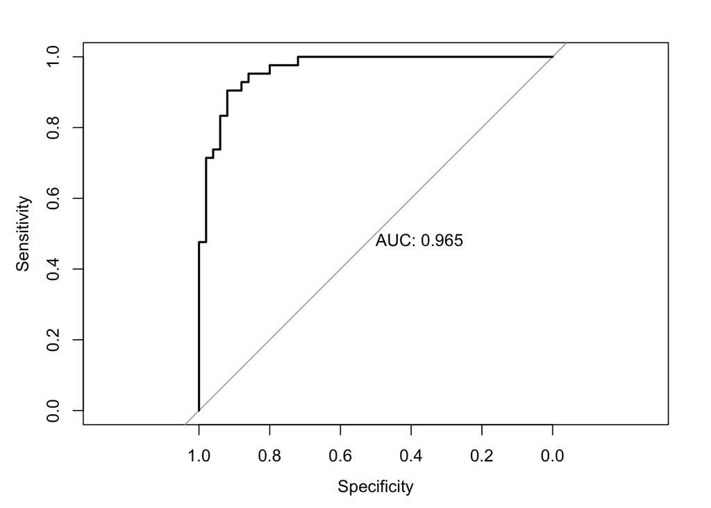

```r
library(pROC)
test_prob = predict(model_log2, newdata = auto_test_data, type = "response")
test_roc = roc(auto_test_data$mpg ~ test_prob, plot = TRUE, print.auc = TRUE)
```

```r
as.numeric(test_roc$auc)
```

```
## [1] 0.9652381
```

This model has a high $AUC = 0.965$

# Exercise 3

Finally we consider the full model and a reduced, improved model.

- Full model: `mpg ~ cylinders + displacement + horsepower + weight + acceleration + year`
- Improved model: `mpg ~ weight + year + horsepower + I(weight^2) + I(year^2)`

We also compare relevant metrics for full model and improved model. The `accuracy` increases from 0.924 to 0.946, `sensitivity` stays the same as 0.976, and `specificity` increases from 0.88 to 0.92. Notice that the overall performance is better than the `full model`. Then we calculate their AUC, respectively.

```r
full_model = glm(mpg ~ ., data = auto_train_data, family = "binomial")
reduced_model = glm(mpg ~ weight + year + horsepower + I(weight^2) + I(year^2), data = auto_train_data, family = "binomial")

test_pred_full = get_pred(full_model, data = auto_test_data, res = "default", pos = "1", neg = "0", cut = 0.5)
test_pred_reduced = get_pred(reduced_model, data = auto_test_data, res = "default", pos = "1", neg = "0", cut = 0.5)

test_tab_full = table(predicted = test_pred_full, actual = auto_test_data$mpg)
test_tab_reduced = table(predicted = test_pred_reduced, actual = auto_test_data$mpg)

test_con_mat_full = confusionMatrix(test_tab_full, positive = "1")
test_con_mat_reduced = confusionMatrix(test_tab_reduced, positive = "1")

metrics = rbind(

  c(test_con_mat_full$overall["Accuracy"],
    test_con_mat_full$byClass["Sensitivity"],
    test_con_mat_full$byClass["Specificity"]),

  c(test_con_mat_reduced$overall["Accuracy"],
    test_con_mat_reduced$byClass["Sensitivity"],
    test_con_mat_reduced$byClass["Specificity"])
)

rownames(metrics) = c("Full model", "Improved model")
round(metrics, 3)
```

```
##                Accuracy Sensitivity Specificity
## Full model        0.924       0.976        0.88
## Improved model    0.946       0.976        0.92
```

```r
test_prob1 = predict(full_model, newdata = auto_test_data, type = "response")
test_roc1 = roc(auto_test_data$mpg ~ test_prob1, print.auc = TRUE)
auc1 = as.numeric(test_roc1$auc)

test_prob2 = predict(reduced_model, newdata = auto_test_data, type = "response")
test_roc2 = roc(auto_test_data$mpg ~ test_prob2, print.auc = TRUE)
auc2 = as.numeric(test_roc2$auc)

auc = rbind(auc1, auc2)
colnames(auc) = "AUC"
rownames(auc) = c("Full model", "Reduced model")
auc
```

```
##                     AUC
## Full model    0.9876190
## Reduced model 0.9895238
```

We know that reduced has higher AUC = 0.9895 > 0.9876, which means the second model is better than full model, with higher accuracy and specificity.